# 20251206_final_outcome

Yu-Chun Huang

2025-12-06

# Background

- **Author**: `<Yu-Chun Huang, Chun-yu Shih>`
- **Created At**: `<2025-12-06>`
- **Research Motivation and Context (why are we interested in the findings?)**:  
  The animal center has to balance the welfare of animals and the efficiency of corporate operations. Analyzing and explaining the staying day of animals can help us to design targeted interventions, such as behavioral training and adoption-matching activities, to reduce operational costs. 儘管動物領養風氣日益盛行，動物收容機構於寵物的安置、管理上仍需面臨龐大的開支。為此，本小組運用美國 Austin 2013 年至今的貓狗領養資料，分析收容天數 LOS (Length of stay day) 與寵物特徵之關係，旨在降低媒合過程中的搜尋摩擦成本，以期優化資源配置。
- **Main Findings and Takeaways**：  
  模型一：在控制其他變數之下，提供證據支持我們在初步進行資料觀察的發現。 模型二：眾多變數均有顯著影響下，我們利用 Random Forest 模型決定出影響力較大的關鍵因子。同時也在給定特徵下，以決策樹模型預測等候收養的長短天數結果。
- **Future Direciton**： 本組在結論發現部分特徵出現不容易被收養的情況，而礙於篇幅，本研究未提供何種方針進一步改善此情況，或許可留待後續研究深入探究。

```r
library(readxl)
library(tidyverse)
library(janitor)
library(lubridate)
library(lmtest)
library(ranger)
library(broom)
library(gt)
library(glue)
library(ggplot2)
library(survival)
library(patchwork)
library(scales)
library(reshape2)
library(webshot2)
library(margins)
```

### Preliminary data clean up: variable preparation and redefinition

```r
# import data
austin <- read.csv("/Users/nnychhi/Desktop/碩二/austin.csv")

# data clean up
austin_clear <- austin %>%
  # drop irrelevant variable
  select(-c("Name", "Found.Location", "Sex.upon.Intake",
            "Date.of.Birth", "Outcome.Subtype", "Age.upon.Outcome")) %>%
  # rename in lower case
  rename_with(tolower) %>%
  # filter for animal and outcome type
  filter(animal.type %in% c("Cat", "Dog"), outcome.type == "Adoption") %>%
  mutate(animal.type = factor(animal.type, levels = c("Dog", "Cat"))) %>% # 0: dog
  # standardized name form
  rename(intake.datetime = intake_datetime,
         outcome.datetime = outcome_datetime) %>%
  # calculate duration of stay
  mutate(start.date = ymd_hms(intake.datetime),
         end.date = ymd_hms(outcome.datetime),
         stay.day.round = round(as.numeric(difftime(end.date, start.date, units = "days")), 2),
         stay.day = floor(as.numeric(difftime(end.date, start.date, units = "days")))) %>%
  # adjustment
  select(-c("outcome.type", "start.date", "end.date"))%>%
  # variable redefined: sex_upon_outcome
  mutate(
    sterilized = case_when(
      grepl("Neutered|Spayed", sex.upon.outcome, ignore.case = TRUE) ~ "Sterilized",
      grepl("Intact", sex.upon.outcome, ignore.case = TRUE) ~ "Intact",
      TRUE ~ "Unknown",
    ),
    sex = case_when(
      sex.upon.outcome == "Unknown" ~ "Unknown",
      TRUE ~ str_to_title(word(sex.upon.outcome, -1))  # pick last word：Male / Female
    ),
    sterilized = factor(sterilized, levels = c("Intact", "Sterilized", "Unknown")), # 0:未絕育
    sex = factor(sex, levels = c("Male", "Female", "Unknown")) # 0: 雄性
  ) %>%
  select(-sex.upon.outcome) %>%
  # variable redefine: breed
  mutate(is_mixed = if_else(str_detect(breed, "Mix|/|-|&"), "Mixed", "Purebred"),
         is_mixed = factor(is_mixed, levels = c("Purebred", "Mixed")) # 0: 純種
         ) %>%
  # variable redefine: color
  mutate(
    color_type = case_when(
      str_detect(color, "(?i)Tabby|Brindle|Tortie|Calico|Merle|Point|Tick|Spotted|Speckled") ~ "Patterned",
      str_count(color, "/|&| ") == 0 ~ "Solid",
      str_count(color, "/|&| ") == 1 ~ "Bicolor",
      str_count(color, "/|&| ") >= 2 ~ "Tricolor+",
      TRUE ~ "Unknown"
    ),
    color_type = factor(color_type, levels = c("Solid", "Bicolor", "Tricolor+", "Patterned")) # 0: 純色
  ) %>%
  # variable redefine: age upon intake -> age_group
  mutate(
    age_years = case_when(
      str_detect(age.upon.intake, "day")   ~ as.numeric(str_extract(age.upon.intake, "\\d+")) / 365,
      str_detect(age.upon.intake, "week")  ~ as.numeric(str_extract(age.upon.intake, "\\d+")) / 52,
      str_detect(age.upon.intake, "month") ~ as.numeric(str_extract(age.upon.intake, "\\d+")) / 12,
      str_detect(age.upon.intake, "year")  ~ as.numeric(str_extract(age.upon.intake, "\\d+")),
      TRUE ~ NA_real_
    ),
    age_group = case_when(
      age_years < 0.5 ~ "Juvenile", # 幼年
      age_years >= 0.5 ~ "Adult", # 成年
      TRUE ~ NA_character_
    ),
    age_group = factor(age_group, levels = c("Adult", "Juvenile")) # 0: 成年
  ) %>%
  select(-age_years) %>%
  # variable redefine: intake condition -> special_condition
  mutate(
    special_condition = case_when(
      intake.condition %in% c("Injured","Sick","Medical","Nursing","Pregnant","Behavior","Feral", "Other")
      ~ "Special",
      TRUE ~ "Normal"
    ),
    special_condition = factor(special_condition, levels = c("Normal", "Special")) # 0: normal condition (special care not needed)
  ) %>%
  # drop intake type unclear
  filter(!intake.type %in% c("Public Assist", "Euthanasia Request")) %>%
  # variable redefine: intake type
  mutate(
    stray = case_when(
      intake.type == "Stray" ~ "Stray",
      intake.type %in% c("Abandoned", "Owner Surrender") ~ "Owned",
      TRUE ~ NA_character_
    ),
    stray = factor(stray, levels = c("Owned", "Stray")) # 0: Owned
  ) %>%
  # adjust variable name form
  rename_with(~ str_replace_all(.x, "\\.", "_"))
```

### Further clean up for analysis: calculate for LOS, outlier exclusion

```r
# prepare variable, check for incomplete and factor levels
# (austin_clear remains some vars for future analysis)
austin_for_analysis <- austin_clear %>%
  # select(-c("intake_datetime", "intake_type", "intake_condition", "stay_day",
  #           "breed", "color", "outcome_datetime")) %>%
  mutate(log_stay_day_round = log1p(stay_day_round)) %>%
  # drop incomplete observations
  filter(if_all(everything(), ~ !is.na(.))) %>%
  filter(
    if_all(where(is.factor),    ~ . != "Unknown") &
      if_all(where(is.character), ~ . != "Unknown")
  ) %>%
  # reorder factor levels
  mutate(
    sterilized = factor(sterilized, levels = c("Intact", "Sterilized")),
    sex = factor(sex, levels = c("Male", "Female")),
    color_type = factor(color_type, levels = c("Solid", "Bicolor", "Tricolor+", "Patterned")),
    age_group = factor(age_group, levels = c("Adult", "Juvenile")),
    special_condition = factor(special_condition, levels = c("Normal", "Special")),
    stray = factor(stray, levels = c("Owned", "Stray"))
  )

# preparing for further dog/ cat specific analysis
 # for dog
austin_for_analysis_dog <- austin_for_analysis %>%
  # filter for dog
  filter(animal_type == "Dog")

 # for cat
austin_for_analysis_cat <- austin_for_analysis %>%
  # filter for cat
  filter(animal_type == "Cat")

# calculate LOS
# 統計兩者收養花費時間 LOS 及其他各變數分佈情況，並以 LOS 之中位數作為分切點，觀察不同變數是否顯著關聯。
los_all <- median(austin_for_analysis$stay_day_round, na.rm = TRUE)
los_dog <- median(austin_for_analysis_dog$stay_day_round, na.rm = TRUE)
los_cat <- median(austin_for_analysis_cat$stay_day_round, na.rm = TRUE)

# outliers determination
# 為避免收容動物有：進入待收養名單時間過短、需長期接受照護等特殊因素，本組限縮觀察資料於已被領養之貓狗，並以 IQR 法排除右尾極端值。
Q1  <- quantile(austin_for_analysis$stay_day_round, 0.25)
Q3  <- quantile(austin_for_analysis$stay_day_round, 0.75)
IQR <- Q3 - Q1

upper <- Q3 + 1.5 * IQR

# for dog
Q1_dog  <- quantile(austin_for_analysis_dog$stay_day_round, 0.25)
Q3_dog  <- quantile(austin_for_analysis_dog$stay_day_round, 0.75)
IQR_dog <- Q3_dog - Q1_dog

upper_dog <- Q3_dog + 1.5 * IQR_dog

# for cat
Q1_cat  <- quantile(austin_for_analysis_cat$stay_day_round, 0.25)
Q3_cat  <- quantile(austin_for_analysis_cat$stay_day_round, 0.75)
IQR_cat <- Q3_cat - Q1_cat

upper_cat <- Q3_cat + 1.5 * IQR_cat

# drop outliers for analysis
austin_for_analysis_all <- austin_for_analysis %>%
  # drop outliers: right tail
  filter(stay_day_round <= upper)%>%
  # create LOS index
  mutate(los_index = as.integer(stay_day_round <= los_all)) # 0: > LOS median

 # for dog
austin_for_analysis_dog <- austin_for_analysis_dog %>%
  # drop outliers: right tail
  filter(stay_day_round <= upper_dog) %>%
  # create LOS index
  mutate(los_index = as.integer(stay_day_round <= los_dog)) # 0: > LOS median

 # for cat
austin_for_analysis_cat <- austin_for_analysis_cat %>%
  # drop outliers: right tail
  filter(stay_day_round <= upper_cat) %>%
  # create LOS index
  mutate(los_index = as.integer(stay_day_round <= los_cat)) # 0: > LOS median
```

### Sanity check and first 10 obs.

```r
nrow(austin_clear)
```

```
## [1] 53007
```

```r
nrow(austin_for_analysis)
```

```
## [1] 53004
```

```r
nrow(austin_for_analysis_all)
```

```
## [1] 49230
```

```r
nrow(austin_for_analysis_dog)
```

```
## [1] 28101
```

```r
nrow(austin_for_analysis_cat)
```

```
## [1] 19885
```

```r
austin_for_analysis_all %>% tabyl(los_index)
```

```
##  los_index     n   percent
##          0 22707 0.4612431
##          1 26523 0.5387569
```

```r
austin_for_analysis_dog %>% tabyl(los_index)
```

```
##  los_index     n  percent
##          0 11976 0.426177
##          1 16125 0.573823
```

```r
austin_for_analysis_cat %>% tabyl(los_index)
```

```
##  los_index     n   percent
##          0  9490 0.4772442
##          1 10395 0.5227558
```

```r
head(austin_for_analysis_all, 10)
```

```
##    animal_id     intake_datetime     intake_type intake_condition animal_type
## 1    A735087 2016-09-18 10:52:00           Stray          Injured         Dog
## 2    A797186 2019-06-10 15:13:00           Stray           Normal         Cat
## 3    A797012 2019-06-08 12:21:00           Stray           Normal         Cat
## 4    A797012 2019-07-21 14:44:00 Owner Surrender           Normal         Cat
## 5    A730005 2016-06-27 11:28:00 Owner Surrender           Normal         Cat
## 6    A673736 2014-03-01 13:51:00           Stray           Normal         Dog
## 7    A694324 2014-12-25 21:40:00           Stray           Normal         Dog
## 8    A827193 2020-12-15 20:37:00           Stray           Normal         Cat
## 9    A733404 2016-08-21 13:07:00           Stray           Normal         Cat
## 10   A815044 2020-03-09 18:19:00           Stray           Normal         Dog
##    age_upon_intake                               breed            color
## 1          3 years              Rhod Ridgeback/Pointer        Tan/White
## 2          3 weeks                Domestic Medium Hair Gray Tabby/White
## 3          1 month              Domestic Shorthair Mix      Brown Tabby
```

[output cut: 29 more lines]

```r
head(austin_for_analysis_dog, 10)
```

```
##    animal_id     intake_datetime     intake_type intake_condition animal_type
## 1    A735087 2016-09-18 10:52:00           Stray          Injured         Dog
## 2    A673736 2014-03-01 13:51:00           Stray           Normal         Dog
## 3    A694324 2014-12-25 21:40:00           Stray           Normal         Dog
## 4    A815044 2020-03-09 18:19:00           Stray           Normal         Dog
## 5    A803354 2019-08-31 11:32:00 Owner Surrender           Normal         Dog
## 6    A770258 2018-04-17 09:44:00           Stray           Normal         Dog
## 7    A736159 2016-10-05 16:43:00           Stray           Normal         Dog
## 8    A736159 2017-04-21 11:04:00           Stray           Normal         Dog
## 9    A699177 2015-03-23 18:41:00           Stray           Normal         Dog
## 10   A746128 2017-03-29 11:08:00           Stray           Normal         Dog
##    age_upon_intake                               breed        color
## 1          3 years              Rhod Ridgeback/Pointer    Tan/White
## 2         13 years              Labrador Retriever Mix        Black
## 3          1 month              Labrador Retriever Mix         Buff
```

[output cut: 29 more lines]

```r
head(austin_for_analysis_cat, 10)
```

```
##    animal_id     intake_datetime     intake_type intake_condition animal_type
## 1    A797186 2019-06-10 15:13:00           Stray           Normal         Cat
## 2    A797012 2019-06-08 12:21:00           Stray           Normal         Cat
## 3    A797012 2019-07-21 14:44:00 Owner Surrender           Normal         Cat
## 4    A730005 2016-06-27 11:28:00 Owner Surrender           Normal         Cat
## 5    A827193 2020-12-15 20:37:00           Stray           Normal         Cat
## 6    A733404 2016-08-21 13:07:00           Stray           Normal         Cat
## 7    A775240 2018-06-26 18:19:00           Stray           Normal         Cat
## 8    A719486 2016-01-21 11:10:00 Owner Surrender           Normal         Cat
## 9    A755040 2017-07-28 14:18:00           Stray           Normal         Cat
## 10   A772086 2018-05-14 14:52:00           Stray           Normal         Cat
##    age_upon_intake                  breed             color    outcome_datetime
## 1          3 weeks   Domestic Medium Hair  Gray Tabby/White 2019-07-08 18:16:00
## 2          1 month Domestic Shorthair Mix       Brown Tabby 2019-07-20 19:04:00
## 3         2 months Domestic Shorthair Mix       Brown Tabby 2019-08-17 11:02:00
```

[output cut: 29 more lines]

## Vaiable definitions

**Table 1. Variable definitions for Austin shelter analysis**

Outcome: los_index (short stay vs. long stay)

| R 變數名稱 | 說明 | 型態 | 可能取值 / 分類 | Base group (參考組) |
| --- | --- | --- | --- | --- |
| animal_type | 動物類別 | factor | Dog, Cat | Dog |
| sex | 性別 | factor | Male, Female | Male |
| sterilized | 被領養時是否絕育 | factor | Intact (未絕育), Sterilized (絕育) | Intact |
| is_mixed | 是否混種品種 | factor | Purebred (純種), Mixed (米克斯) | Purebred |
| color_type | 顏色類型 | factor | Solid (純色), Bicolor (雙色), Tricolor+ (三色,含以上), Patterned (特殊斑紋) | Solid |
| age_group | 年齡組別 | factor | Adult (成年), Juvenile (幼年, 小於六個月) | Adult |
| special_condition | 入所條件是否特殊 | factor | Normal, Special (需特殊照顧) | Normal |
| stray | 是否曾與人生活 | factor | Owned (曾被飼養), Stray (流浪) | Owned |
| stay_day_round | 收容天數 (取到第二位) | numeric | 連續數值（天數） | NA |
| los_index | 是否為短收容：1 = stay ≤ median LOS | binary (0/1) | 0 = 長於中位數; 1 = 短於或等於中位數 | NA |

## Summary statistics

```r
# ============================================================
# Summary statistics for ALL variables used in the 5 models
# All treated as categorical (including los_index)
# 統計資料分佈型態，發現貓、狗的收養天數絕大部分皆低於 25 天。
# 進入收容機構的貓、狗性別比例幾乎相等。
# 而在健康狀況、品種、結紮與否則呈現不對稱的比例分佈，絕大部分的貓狗均為健康正常、已結紮且混種的情況。
# 然而我們以六個月為基準將貓狗分為幼年、成年，以及毛色部分，貓狗則有不同的分佈情況。
# ============================================================

vars_all <- c(
  "los_index",
  "animal_type",
  "sex",
  "is_mixed",
  "color_type",
  "sterilized",
  "age_group",
  "special_condition",
  "stray"
)

cat_summary <- austin_for_analysis_all %>%
  select(all_of(vars_all)) %>%
  mutate(across(everything(), as.character)) %>%
  pivot_longer(
    cols      = everything(),
    names_to  = "variable",
    values_to = "level"
  ) %>%
  filter(!is.na(level)) %>%
  count(variable, level, name = "count") %>%
  group_by(variable) %>%
  mutate(
    percent = count / sum(count)
  ) %>%
  slice_max(order_by = count, n = 10, with_ties = FALSE) %>%
  arrange(variable, desc(count)) %>%
  ungroup()

cat_summary
```

```
## # A tibble: 20 × 4
##    variable          level      count percent
##    <chr>             <chr>      <int>   <dbl>
##  1 age_group         Adult      26727 0.543
##  2 age_group         Juvenile   22503 0.457
##  3 animal_type       Dog        30161 0.613
##  4 animal_type       Cat        19069 0.387
##  5 color_type        Bicolor    22013 0.447
##  6 color_type        Patterned  14609 0.297
##  7 color_type        Solid      12532 0.255
##  8 color_type        Tricolor+     76 0.00154
##  9 is_mixed          Mixed      42072 0.855
## 10 is_mixed          Purebred    7158 0.145
## 11 los_index         1          26523 0.539
## 12 los_index         0          22707 0.461
## 13 sex               Male       24897 0.506
## 14 sex               Female     24333 0.494
## 15 special_condition Normal     46091 0.936
## 16 special_condition Special     3139 0.0638
## 17 sterilized        Sterilized 47363 0.962
## 18 sterilized        Intact      1867 0.0379
## 19 stray             Stray      35385 0.719
## 20 stray             Owned      13845 0.281
```

## Summary plots

```r
# plots preparation
austin_analysis_plot <- austin_for_analysis_all %>%
  mutate(
    los_index_f = factor(
      ifelse(los_index == 1, "<=LOS", ">LOS"),
      levels = c("<=LOS", ">LOS")
    ),
    special_condition = factor(special_condition, levels = c("Normal", "Special"))
  )

# theme ---------------------------------------------------------
theme_plot <- theme_minimal(base_size = 13) +
  theme(
    plot.title = element_text(face = "bold", hjust = 0),
    strip.text = element_text(face = "bold"),
    axis.text.x = element_text(angle = 20, hjust = 1)
  )

# y-axis：0–100% -----------------------------
scale_prop <- scale_y_continuous(
  labels = percent_format(),
  limits = c(0, 1),
  expand = expansion(mult = c(0, 0.02))
)
```

### Plot A

```r
# ====================================================================
# A. 第一張：LOS / age_group / LOS_index / special_condition
#    （整體 & 分別貓狗）
# ====================================================================

## row1: stay_day_round 分布（整體 / Dog / Cat） -----------------------

pA1_all <- ggplot(austin_analysis_plot, aes(x = stay_day_round)) +
  geom_histogram(binwidth = 5, fill = "skyblue", color = "white") +
  labs(
    title = "All animals",
    x = "Stay days (rounded)",
    y = "Count"
  ) +
  theme_plot

pA1_dog <- austin_analysis_plot %>%
  filter(animal_type == "Dog") %>%
  ggplot(aes(x = stay_day_round)) +
  geom_histogram(binwidth = 5, fill = "skyblue", color = "white") +
  labs(
    title = "Dogs",
    x = "Stay days (rounded)",
    y = "Count"
  ) +
  theme_plot

pA1_cat <- austin_analysis_plot %>%
  filter(animal_type == "Cat") %>%
  ggplot(aes(x = stay_day_round)) +
  geom_histogram(binwidth = 5, fill = "skyblue", color = "white") +
  labs(
    title = "Cats",
    x = "Stay days (rounded)",
    y = "Count"
  ) +
  theme_plot

rowA1 <- pA1_all | pA1_dog | pA1_cat

## row2: age_group 比例（整體 / Dog / Cat） ---------------------------

pA2_all <- ggplot(austin_analysis_plot, aes(x = age_group)) +
  geom_bar(aes(y = after_stat(prop), group = 1), fill = "grey60") +
  scale_prop +
  labs(
    title = "All animals",
    x = "Age group",
    y = "Proportion"
  ) +
  theme_plot

pA2_dog <- austin_analysis_plot %>%
  filter(animal_type == "Dog") %>%
  ggplot(aes(x = age_group)) +
  geom_bar(aes(y = after_stat(prop), group = 1), fill = "grey60") +
  scale_prop +
  labs(
    title = "Dogs",
    x = "Age group",
    y = "Proportion"
  ) +
  theme_plot

pA2_cat <- austin_analysis_plot %>%
  filter(animal_type == "Cat") %>%
  ggplot(aes(x = age_group)) +
  geom_bar(aes(y = after_stat(prop), group = 1), fill = "grey60") +
  scale_prop +
  labs(
    title = "Cats",
    x = "Age group",
    y = "Proportion"
  ) +
  theme_plot

rowA2 <- pA2_all | pA2_dog | pA2_cat

## row3: LOS_index 比例（整體 / Dog / Cat） --------------------------
# 觀察不同特徵下，貓狗的收養天數差異。survival curve 顯示給定相同天數下，狗狗被收養的比例大於貓咪被收養的比例，顯示美國市場對於貓、狗的偏好差異。
# 因此我們在後續的模型中，貓、狗均分別討論。

pA3_all <- ggplot(austin_analysis_plot, aes(x = los_index_f)) +
  geom_bar(aes(y = after_stat(prop), group = 1), fill = "seagreen3") +
  scale_prop +
  labs(
    title = "All animals",
    x = "LOS group (median cutoff)",
    y = "Proportion"
  ) +
  theme_plot

pA3_dog <- austin_analysis_plot %>%
  filter(animal_type == "Dog") %>%
  ggplot(aes(x = los_index_f)) +
  geom_bar(aes(y = after_stat(prop), group = 1), fill = "seagreen3") +
  scale_prop +
  labs(
    title = "Dogs",
    x = "LOS group (median cutoff)",
    y = "Proportion"
  ) +
  theme_plot

pA3_cat <- austin_analysis_plot %>%
  filter(animal_type == "Cat") %>%
  ggplot(aes(x = los_index_f)) +
  geom_bar(aes(y = after_stat(prop), group = 1), fill = "seagreen3") +
  scale_prop +
  labs(
    title = "Cats",
    x = "LOS group (median cutoff)",
    y = "Proportion"
  ) +
  theme_plot

rowA3 <- pA3_all | pA3_dog | pA3_cat

## row4: special_condition 比例（整體 / Dog / Cat） -------------------

pA4_all <- ggplot(austin_analysis_plot, aes(x = special_condition)) +
  geom_bar(aes(y = after_stat(prop), group = 1), fill = "tomato") +
  scale_prop +
  labs(
    title = "All animals",
    x = "Intake condition",
    y = "Proportion"
  ) +
  theme_plot

pA4_dog <- austin_analysis_plot %>%
  filter(animal_type == "Dog") %>%
  ggplot(aes(x = special_condition)) +
  geom_bar(aes(y = after_stat(prop), group = 1), fill = "tomato") +
  scale_prop +
  labs(
    title = "Dogs",
    x = "Intake condition",
    y = "Proportion"
  ) +
  theme_plot

pA4_cat <- austin_analysis_plot %>%
  filter(animal_type == "Cat") %>%
  ggplot(aes(x = special_condition)) +
  geom_bar(aes(y = after_stat(prop), group = 1), fill = "tomato") +
  scale_prop +
  labs(
    title = "Cats",
    x = "Intake condition",
    y = "Proportion"
  ) +
  theme_plot

rowA4 <- pA4_all | pA4_dog | pA4_cat
```

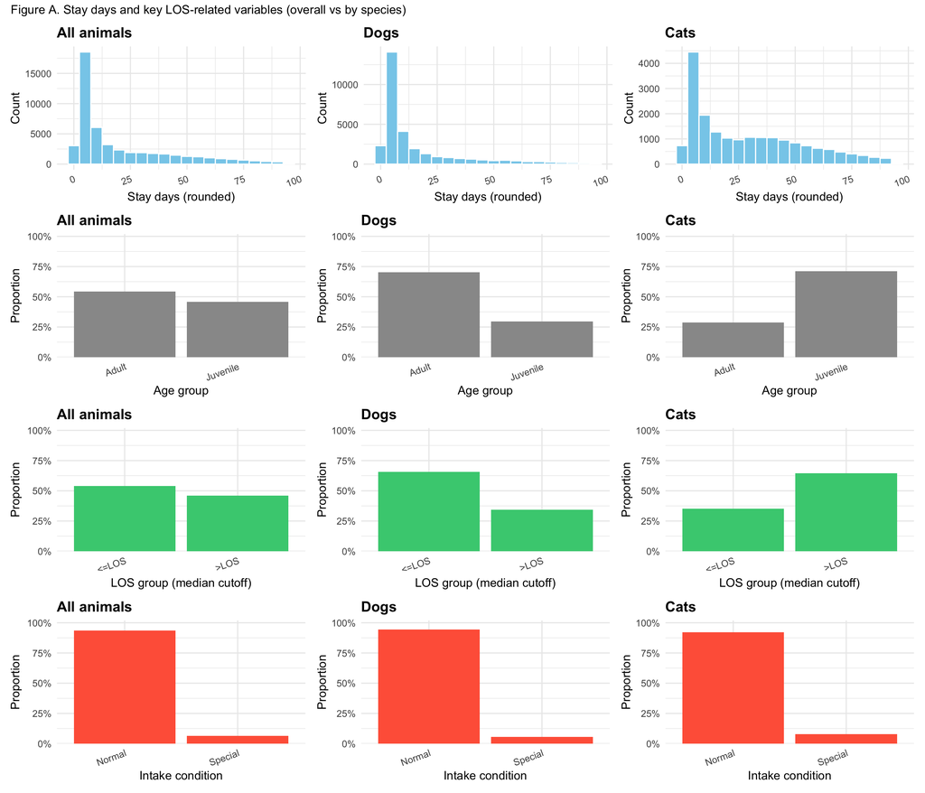

```r
## Figure A -----------------------------------------------------------

fig_A <- (rowA1 / rowA2 / rowA3 / rowA4) +
  plot_annotation(title = "Figure A. Stay days and key LOS-related variables (overall vs by species)")
fig_A
```

####Save plot A

```r
ggsave("/Users/nnychhi/Desktop/austin_outputs/Figure_A.png", fig_A, width = 14, height = 12, dpi = 300)
```

### Plot B

```r
# ====================================================================
# B. 第二張：貓狗分別的 sex / is_mixed / color_type / sterilized 比率
# ====================================================================

make_species_prop_row <- function(var_name, xlab) {
  var_sym <- rlang::sym(var_name)

  # Dogs
  df_dog <- austin_analysis_plot %>%
    filter(animal_type == "Dog") %>%
    count(!!var_sym, name = "n") %>%
    mutate(prop = n / sum(n))

  p_dog <- ggplot(df_dog, aes(x = !!var_sym, y = prop, fill = !!var_sym)) +
    geom_col() +
    scale_prop +
    labs(
      title = paste0("Dogs - ", xlab),
      x = xlab,
      y = "Proportion",
      fill = xlab
    ) +
    theme_plot

  # Cats
  df_cat <- austin_analysis_plot %>%
    filter(animal_type == "Cat") %>%
    count(!!var_sym, name = "n") %>%
    mutate(prop = n / sum(n))

  p_cat <- ggplot(df_cat, aes(x = !!var_sym, y = prop, fill = !!var_sym)) +
    geom_col() +
    scale_prop +
    labs(
      title = paste0("Cats - ", xlab),
      x = xlab,
      y = "Proportion",
      fill = xlab
    ) +
    theme_plot

  p_dog | p_cat
}

rowB1 <- make_species_prop_row("sex", "Sex")
rowB2 <- make_species_prop_row("is_mixed", "Breed type")
rowB3 <- make_species_prop_row("color_type", "Color type")
rowB4 <- make_species_prop_row("sterilized", "Sterilization status")
```

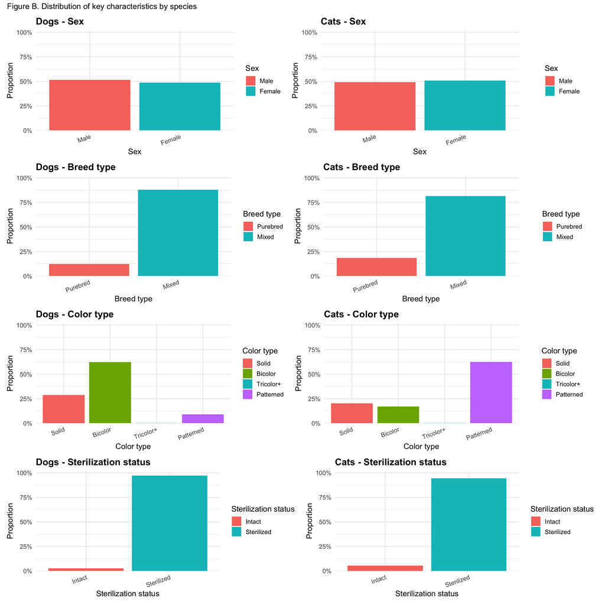

```r
fig_B <- (rowB1 / rowB2 / rowB3 / rowB4) +
  plot_annotation(title = "Figure B. Distribution of key characteristics by species")
fig_B
```

####Save plot B

```r
ggsave("/Users/nnychhi/Desktop/austin_outputs/Figure_B.png", fig_B, width = 14, height = 14, dpi = 300)
```

### Plot C1

```r
# ====================================================================
# C. 第三張：LOS group（<=LOS vs >LOS）下的組成差異：不堆疊版本
#    → C1：overall；C2：分物種
# ====================================================================

## 1. LOS vs special_condition（每個 LOS panel 裡 Normal / Special 各一根） ----

dfC1_cond <- austin_analysis_plot %>%
  group_by(los_index_f, special_condition) %>%
  summarise(n = n(), .groups = "drop") %>%
  group_by(los_index_f) %>%
  mutate(prop = n / sum(n))

pC1 <- ggplot(dfC1_cond,
              aes(x = special_condition, y = prop, fill = special_condition)) +
  geom_col() +
  scale_prop +
  facet_wrap(~ los_index_f) +
  labs(
    title = "Special intake condition by LOS group",
    x = "Intake condition",
    y = "Proportion",
    fill = "Intake condition"
  ) +
  theme_plot

## 2. LOS vs stray
dfC1_stray <- austin_analysis_plot %>%
  group_by(los_index_f, stray) %>%
  summarise(n = n(), .groups = "drop") %>%
  group_by(los_index_f) %>%
  mutate(prop = n / sum(n))

pC_stray <- ggplot(dfC1_stray,
                   aes(x = stray, y = prop, fill = stray)) +
  geom_col() +
  scale_prop +
  facet_wrap(~ los_index_f) +
  labs(
    title = "Stray vs Owned by LOS group",
    x = "Origin (Stray / Owned)",
    y = "Proportion",
    fill = "Origin"
  ) +
  theme_plot

## 3. LOS vs animal_type（每個 LOS panel 裡 Dog / Cat 各一根） -------------

dfC1_spec <- austin_analysis_plot %>%
  group_by(los_index_f, animal_type) %>%
  summarise(n = n(), .groups = "drop") %>%
  group_by(los_index_f) %>%
  mutate(prop = n / sum(n))

pC2 <- ggplot(dfC1_spec,
              aes(x = animal_type, y = prop, fill = animal_type)) +
  geom_col() +
  scale_prop +
  facet_wrap(~ los_index_f) +
  labs(
    title = "Species composition by LOS group",
    x = "Species",
    y = "Proportion",
    fill = "Species"
  ) +
  theme_plot
```

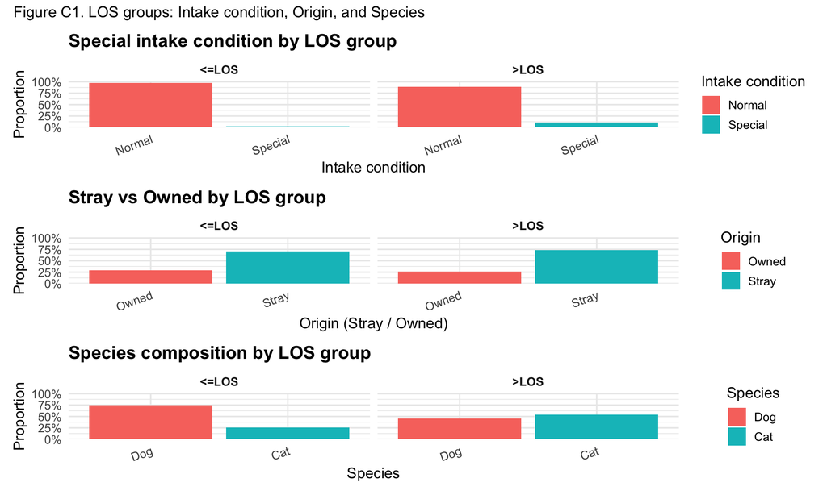

```r
fig_C1 <- (pC1 / pC_stray / pC2) +
  plot_annotation(title = "Figure C1. LOS groups: Intake condition, Origin, and Species")
fig_C1
```

####Save plot C1

```r
ggsave("/Users/nnychhi/Desktop/austin_outputs/Figure_C1.png", fig_C1, width = 10, height = 6, dpi = 300)
```

### Plot C2

```r
## C2：Dog / Cat × LOS，類別用「並排 bar」（不堆疊） -------------------
# Intake condition 若為 Special，表示貓狗在進入收容機構時可能有受傷、生病或懷孕等特殊情況。
# Special 中收容天數低於 LOS 的比例明顯較高於 LOS 的比例更少（我們將 LOS 以中位數為基準切分，因此兩群體的比例大約各半）。

make_C2_plot <- function(var_name, fill_lab, title_text) {
  var_sym <- rlang::sym(var_name)

  df <- austin_analysis_plot %>%
    group_by(animal_type, los_index_f, !!var_sym) %>%
    summarise(n = n(), .groups = "drop") %>%
    group_by(animal_type, los_index_f) %>%
    mutate(prop = n / sum(n))

  ggplot(
    df,
    aes(
      x = los_index_f,
      y = prop,
      fill = !!var_sym,
      group = !!var_sym   # 明確告訴 ggplot：以類別分組來 dodge
    )
  ) +
    geom_col(position = "dodge") +   # 不再是 stack
    scale_prop +
    facet_wrap(~ animal_type) +
    labs(
      title = title_text,
      x = "LOS group (median cutoff)",
      y = "Proportion",
      fill = fill_lab
    ) +
    theme_plot
}

pC3 <- make_C2_plot(
  var_name   = "sex",
  fill_lab   = "Sex",
  title_text = "Sex composition by LOS group and species"
)

pC4 <- make_C2_plot(
  var_name   = "age_group",
  fill_lab   = "Age group",
  title_text = "Age group composition by LOS group and species"
)

pC5 <- make_C2_plot(
  var_name   = "is_mixed",
  fill_lab   = "Breed type",
  title_text = "Breed type composition by LOS group and species"
)

pC6 <- make_C2_plot(
  var_name   = "color_type",
  fill_lab   = "Color type",
  title_text = "Color type composition by LOS group and species"
)

pC7 <- make_C2_plot(
  var_name   = "sterilized",
  fill_lab   = "Sterilization",
  title_text = "Sterilization status by LOS group and species"
)
```

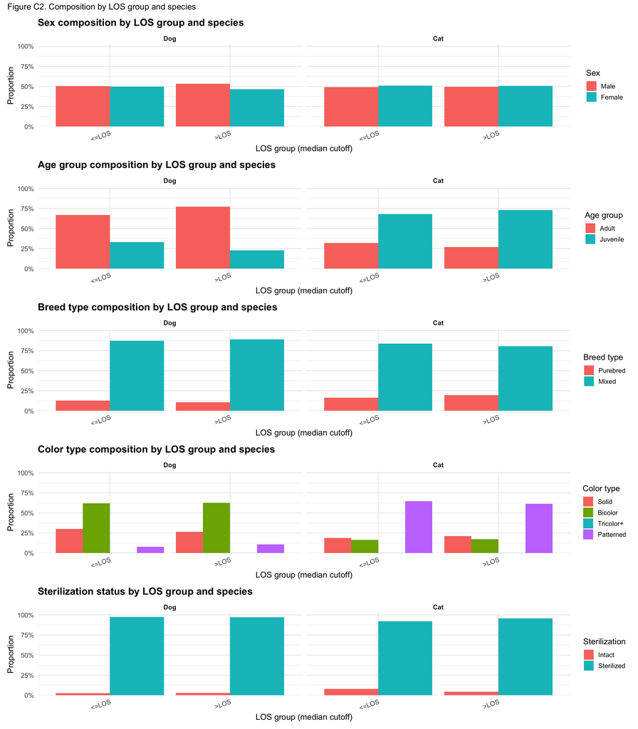

```r
fig_C2 <- (pC3 / pC4 / pC5 / pC6 / pC7) +
  plot_annotation(title = "Figure C2. Composition by LOS group and species")
fig_C2
```

####Save plot C2

```r
ggsave("/Users/nnychhi/Desktop/austin_outputs/Figure_C2.png", fig_C2, width = 14, height = 16, dpi = 300)
```

### Plot D

```r
# ====================================================================
# D. 熱力圖：LOS
# ====================================================================

# 要放進 heatmap 的類別變數
vars_cat <- c(
  "animal_type",
  "sex",
  "age_group",
  "sterilized",
  "special_condition",
  "is_mixed",
  "color_type",
  "stray"
)

# 建立 summary for all：每個變數 × 每個 level 的 LOS 指標
los_summary <- map_df(vars_cat, function(v) {
  austin_analysis_plot %>%
    group_by(level = .data[[v]]) %>%      # 用 level 暫存每個類別
    summarise(
      n          = n(),
      median_los = median(stay_day_round),
      mean_los   = mean(stay_day_round),
      prop_short = mean(los_index == 1),  # <= overall median LOS 的比例
      .groups    = "drop"
    ) %>%
    mutate(
      variable = v,
      level    = fct_inorder(level)       # 保留原本的順序
    )
}) %>%
  mutate(
    variable = factor(variable, levels = vars_cat)  # 控制欄順序
  )

# D1：overall heatmap
fig_D1 <- ggplot(los_summary,
                 aes(x = variable, y = level, fill = median_los)) +
  geom_tile(color = "white") +
  scale_fill_gradient(
    name = "Median LOS\n(days)",
    low = "white",
    high = "steelblue"
  ) +
  labs(
    title = "Figure D1. Median LOS by category (Overall)",
    x = "Variable",
    y = "Category level"
  ) +
  theme_minimal(base_size = 13) +
  theme(
    axis.text.x = element_text(angle = 30, hjust = 1),
    plot.title  = element_text(face = "bold", hjust = 0),
    panel.grid  = element_blank()
  )

# summary by animal type
los_summary_by_species <- map_df(vars_cat, function(v) {
  austin_analysis_plot %>%
    group_by(animal_type, level = .data[[v]]) %>%
    summarise(
      n          = n(),
      median_los = median(stay_day_round),
      mean_los   = mean(stay_day_round),
      prop_short = mean(los_index == 1),
      .groups    = "drop"
    ) %>%
    mutate(
      variable = v,
      level    = fct_inorder(level)
    )
}) %>%
  mutate(
    variable = factor(variable, levels = vars_cat)
  )

# D2：by species heatmap
fig_D2 <- ggplot(los_summary_by_species,
                 aes(x = variable, y = level, fill = median_los)) +
  geom_tile(color = "white") +
  scale_fill_gradient(
    name = "Median LOS\n(days)",
    low = "white",
    high = "steelblue"
  ) +
  facet_wrap(~ animal_type) +
  labs(
    title = "Figure D2. Median LOS by category and species",
    x = "Variable",
    y = "Category level"
  ) +
  theme_minimal(base_size = 13) +
  theme(
    axis.text.x = element_text(angle = 30, hjust = 1),
    strip.text  = element_text(face = "bold"),
    plot.title  = element_text(face = "bold", hjust = 0),
    panel.grid  = element_blank()
  )
```

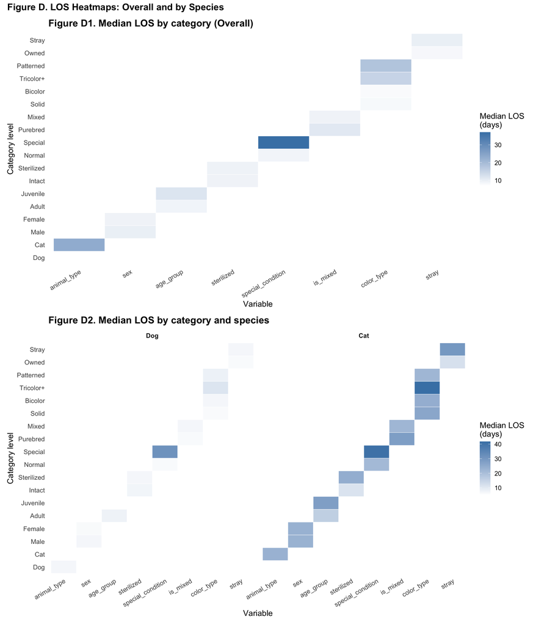

```r
fig_D <- fig_D1 / fig_D2 +
  plot_annotation(
    title = "Figure D. LOS Heatmaps: Overall and by Species",
    theme = theme(plot.title = element_text(face = "bold", size = 15, hjust = 0))
  )

fig_D
```

####Save plot D

```r
# ggsave("/Users/nnychhi/Desktop/austin_outputs/Figure_D.png", fig_D, width = 12, height = 14, dpi = 300)
# ---
```

## Analysis part

### Our hypothesis

1. animal type：貓狗停留天數有顯著差異
2. sex：領養人對於貓狗存在性別偏好
3. is_mixed：純種貓狗停留天數更短
4. sterilized：絕育貓狗停留天數更短
5. color_type：顏色較單純或是帶有特殊斑紋的貓狗停留天數更短
6. age_group：幼年貓狗停留天數更短一些
7. special_condition：入所時需要特殊照顧的貓狗停留天數更長
8. stray：曾與人類生活過的貓狗停留天數更短
- los_index定義為停留天數是否低於停留天數中位數，停留天數更短也可表示為更容易被領養

然而以上關係可能係受到其他效果的間接影響。例如已經結紮的貓咪較容易被收養可能主因為該群體貓咪多半已成年，成年的貓咪又較不受到收養者的喜好。 因此我們需進一步以迴歸模型控制其他變因，藉以驗證資料初步的觀察。

```r
# func for result saving
# !!這函數要改dir存檔!!
save_all_outputs <- function(plot_obj, table_obj, name,
                             base_dir = "/Users/nnychhi/Desktop/austin_outputs") {

  fig_dir   <- file.path(base_dir, "fig")
  table_dir <- file.path(base_dir, "table")

  if(!dir.exists(fig_dir))   dir.create(fig_dir, recursive = TRUE)
  if(!dir.exists(table_dir)) dir.create(table_dir, recursive = TRUE)

  # 1. plot
  ggsave(file.path(fig_dir, paste0(name, "_plot.png")),
         plot = plot_obj, width = 10, height = 6, dpi = 300)

  # 2. table html
  html_file <- file.path(table_dir, paste0(name, "_table.html"))
  gtsave(table_obj, html_file)

  # 3. table png
  webshot2::webshot(html_file,
                    file = file.path(table_dir, paste0(name, "_table.png")),
                    zoom = 2)
}
```

## A. LPM: all

```r
# LPM: all ---
# 利用二元變數迴歸模型，設定被解釋變數 Y = 1 表示貓、狗收養天數 < median LOS，亦即較快被領養。
# 因此係數的正、負方向即分別代表領養速度的快、慢。表格標題所列之類別變數則代表該特徵 = 1，例如雌性的狗則 Female = 1。

lpm_all <- lm(
  los_index ~ animal_type + sex + is_mixed + color_type +
    sterilized + age_group + special_condition + stray,
  data = austin_for_analysis_all
)

lpm_all_summary <- tidy(lpm_all, conf.int = TRUE)

# HC1 robust variance
vc_hc1_lpm_all <- sandwich::vcovHC(lpm_all, type = "HC1")
tidy_lpm_hc1 <- broom::tidy(lpm_all, conf.int = TRUE, vcov = vc_hc1_lpm_all)
```

### a.1 Coefficient plot: LPM_all

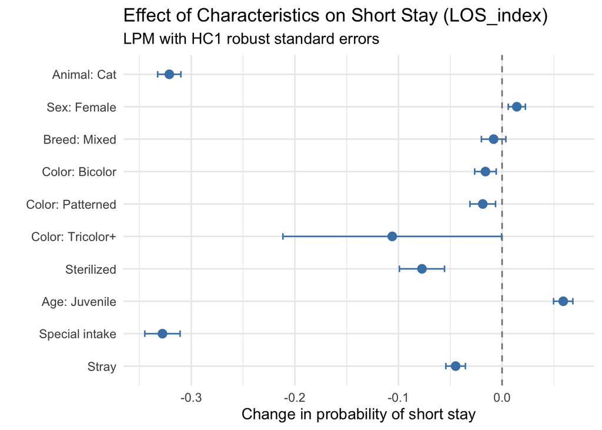

```r
# star function for coefficient table
star <- function(p){
  ifelse(p < 0.01, "***",
         ifelse(p < 0.05, "**",
                ifelse(p < 0.10, "*", "")))
}

# prepare for coefficient plot
coef_order_lpm <- c(
  "Animal: Cat",
  "Sex: Female",
  "Breed: Mixed",
  "Color: Bicolor",
  "Color: Patterned",
  "Color: Tricolor+",
  "Sterilized",
  "Age: Juvenile",
  "Special intake",
  "Stray"
)

coef_plot_lpm <- tidy_lpm_hc1 %>%
  filter(term != "(Intercept)") %>%
  mutate(
    term = recode(
      term,
      "animal_typeCat"           = "Animal: Cat",
      "sexFemale"                = "Sex: Female",
      "is_mixedMixed"            = "Breed: Mixed",
      "color_typeBicolor"        = "Color: Bicolor",
      "color_typePatterned"      = "Color: Patterned",
      "color_typeTricolor+"      = "Color: Tricolor+",
      "sterilizedSterilized"     = "Sterilized",
      "age_groupJuvenile"        = "Age: Juvenile",
      "special_conditionSpecial" = "Special intake",
      "strayStray"               = "Stray"
    ),
    term = factor(term, levels = rev(coef_order_lpm))
  )

 # coefficient plot: lpm, All
plot_lpm_all <- ggplot(coef_plot_lpm, aes(x = term, y = estimate)) +
  geom_point(size = 3, color = "steelblue") +
  geom_errorbar(aes(ymin = conf.low, ymax = conf.high),
                width = 0.2, color = "steelblue") +
  geom_hline(yintercept = 0, linetype = "dashed", color = "gray50") +
  coord_flip() +
  labs(
    title = "Effect of Characteristics on Short Stay (LOS_index)",
    subtitle = "LPM with HC1 robust standard errors",
    x = "",
    y = "Change in probability of short stay"
  ) +
  theme_minimal(base_size = 13)
  plot_lpm_all
```

### a.2 Result table: LPM_all

```r
# prepare for result table
tbl_lpm_all <- tidy_lpm_hc1 %>%
  filter(term != "(Intercept)") %>%
  mutate(
    term = recode(
      term,
      "animal_typeCat"           = "Animal: Cat",
      "sexFemale"                = "Sex: Female",
      "is_mixedMixed"            = "Breed: Mixed",
      "color_typeBicolor"        = "Color: Bicolor",
      "color_typePatterned"      = "Color: Patterned",
      "color_typeTricolor+"      = "Color: Tricolor+",
      "sterilizedSterilized"     = "Sterilized",
      "age_groupJuvenile"        = "Age: Juvenile",
      "special_conditionSpecial" = "Special intake",
      "strayStray"               = "Stray"
    ),
    sig  = star(p.value),
    est_with_star = ifelse(
      sig == "",
      sprintf("%.3f", estimate),
      sprintf("%.3f<sup>%s</sup>", estimate, sig)
    ),
    ci_col = sprintf("[%.3f, %.3f]", conf.low, conf.high)
  ) %>%
  transmute(
    Term = term,
    Estimate = est_with_star,
    `Std. Error (HC1)` = sprintf("%.3f", std.error),
    `95% CI` = ci_col,
    `p-value` = sprintf("%.3f", p.value)
  )

 # result table
g_stats_lpm <- glance(lpm_all)
y_mean_lpm  <- mean(austin_for_analysis_all$los_index, na.rm = TRUE)

result_tbl_lpm_all <- tbl_lpm_all %>%
  gt() %>%
  tab_header(
    title = md("**LPM results with HC1 robust standard errors**"),
    subtitle = md(
      glue("Outcome: **los_index** (1 = stay ≤ overall median LOS).  ",
           "Mean outcome = **{sprintf('%.3f', y_mean_lpm)}**")
    )
  ) %>%
  fmt_markdown(columns = "Estimate") %>%
  cols_label(
    Term = "Variable",
    Estimate = "Estimate",
    `Std. Error (HC1)` = "Std. Error (HC1)",
    `95% CI` = "95% CI",
    `p-value` = "p-value"
  ) %>%
  cols_align(
    align = "left",
    columns = c(Term)
  ) %>%
  cols_align(
    align = "right",
    columns = c("Estimate", "Std. Error (HC1)", "95% CI", "p-value")
  ) %>%
  tab_source_note(
    source_note = md(
      paste0(
        "**Base groups:** Animal = Dog; Sterilization = Intact; Sex = Male; ",
        "Breed = Purebred; Color = Solid; Age = Adult; ",
        "Intake condition = Normal; Origin = Owned."
      )
    )
  ) %>%
  tab_style(
    style = list(
      cell_text(size = "smaller", color = "gray40", align = "left")
    ),
    locations = cells_source_notes()
  ) %>%
  opt_row_striping()

result_tbl_lpm_all
```

**LPM results with HC1 robust standard errors**

Outcome: **los_index** (1 = stay ≤ overall median LOS). Mean outcome = **0.539**

| Variable | Estimate | Std. Error (HC1) | 95% CI | p-value |
| --- | --- | --- | --- | --- |
| Animal: Cat | -0.321*** | 0.006 | [-0.332, -0.310] | 0.000 |
| Sex: Female | 0.014*** | 0.004 | [0.006, 0.022] | 0.001 |
| Breed: Mixed | -0.008 | 0.006 | [-0.020, 0.004] | 0.174 |
| Color: Bicolor | -0.016*** | 0.005 | [-0.026, -0.006] | 0.002 |
| Color: Tricolor+ | -0.106** | 0.054 | [-0.212, -0.000] | 0.049 |
| Color: Patterned | -0.019*** | 0.006 | [-0.031, -0.006] | 0.003 |
| Sterilized | -0.077*** | 0.011 | [-0.099, -0.056] | 0.000 |
| Age: Juvenile | 0.059*** | 0.005 | [0.050, 0.068] | 0.000 |
| Special intake | -0.328*** | 0.009 | [-0.345, -0.311] | 0.000 |
| Stray | -0.045*** | 0.005 | [-0.054, -0.035] | 0.000 |

**Base groups:** Animal = Dog; Sterilization = Intact; Sex = Male; Breed = Purebred; Color = Solid; Age = Adult; Intake condition = Normal; Origin = Owned.

### a.3 Save table & plot

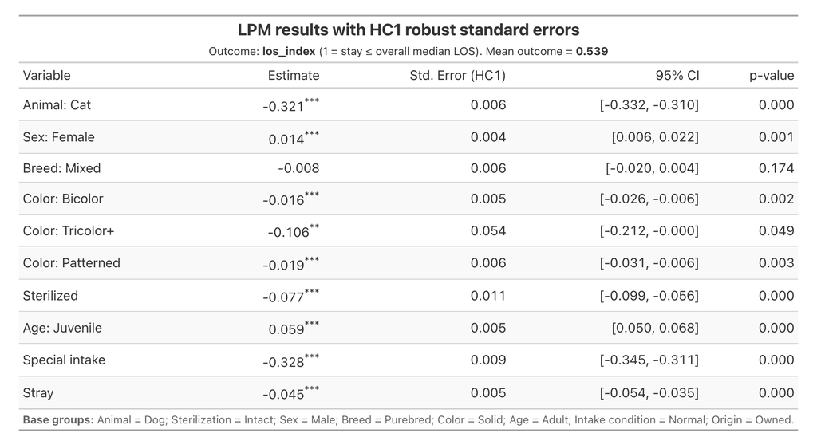

```r
# save table & plot
save_all_outputs(
  plot_obj  = plot_lpm_all,
  table_obj = result_tbl_lpm_all,
  name      = "lpm_all"
)
```

## B. LPM: Dog

```r
# 根據 LPM 和 Logit 兩模型的結果，影響較顯著的是 Special Intake。
# 在控制其他條件不變下，進入收容中心若是具如受傷、懷孕等特殊情形，較一般情況下，更快被收養的機率降低 35.5%。可能原因為具有特殊情況的寵物需要花費時間進行治療、協助生產等。
# 次之則是幼犬具有較高的短期收養機率，第三個影響因子則是毛色越多，短期內被收養的機率越低，反映市場較不喜愛三色狗。而這三者迴歸結果均與此前的研究假設相符。
lpm_dog <- lm(
  los_index ~ sex + is_mixed + color_type +
    sterilized + age_group + special_condition + stray,
  data = austin_for_analysis_dog
)

lpm_dog_summary <- tidy(lpm_dog, conf.int = TRUE)

# HC1 robust variance
vc_hc1_lpm_dog <- sandwich::vcovHC(lpm_dog, type = "HC1")
tidy_lpm_dog_hc1 <- broom::tidy(lpm_dog, conf.int = TRUE, vcov = vc_hc1_lpm_dog)
```

### b.1 Coefficient plot: LPM_dog

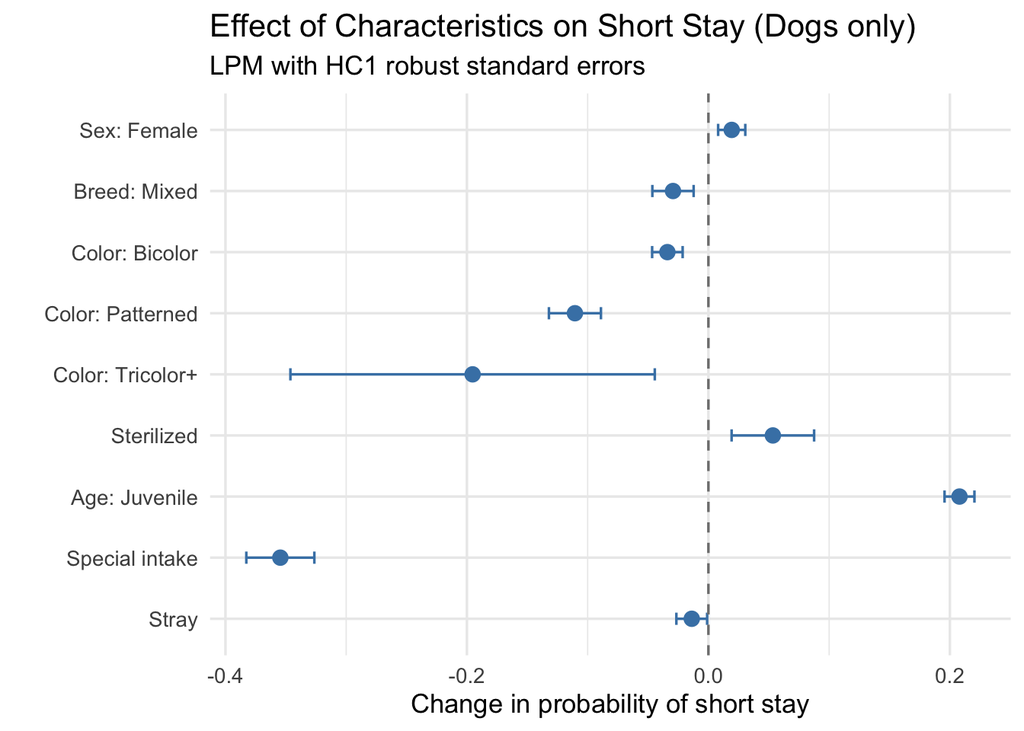

```r
# prepare for coefficient plot
coef_order_lpm_dog <- c(
  "Sex: Female",
  "Breed: Mixed",
  "Color: Bicolor",
  "Color: Patterned",
  "Color: Tricolor+",
  "Sterilized",
  "Age: Juvenile",
  "Special intake",
  "Stray"
)

coef_plot_lpm_dog <- tidy_lpm_dog_hc1 %>%
  filter(term != "(Intercept)") %>%
  mutate(
    term = recode(
      term,
      "sexFemale"                = "Sex: Female",
      "is_mixedMixed"            = "Breed: Mixed",
      "color_typeBicolor"        = "Color: Bicolor",
      "color_typePatterned"      = "Color: Patterned",
      "color_typeTricolor+"      = "Color: Tricolor+",
      "sterilizedSterilized"     = "Sterilized",
      "age_groupJuvenile"        = "Age: Juvenile",
      "special_conditionSpecial" = "Special intake",
      "strayStray"               = "Stray"
    ),
    term = factor(term, levels = rev(coef_order_lpm_dog))
  )

 # coefficient plot: lpm, Dog
plot_lpm_dog <- ggplot(coef_plot_lpm_dog, aes(x = term, y = estimate)) +
  geom_point(size = 3, color = "steelblue") +
  geom_errorbar(aes(ymin = conf.low, ymax = conf.high),
                width = 0.2, color = "steelblue") +
  geom_hline(yintercept = 0, linetype = "dashed", color = "gray50") +
  coord_flip() +
  labs(
    title = "Effect of Characteristics on Short Stay (Dogs only)",
    subtitle = "LPM with HC1 robust standard errors",
    x = "",
    y = "Change in probability of short stay"
  ) +
  theme_minimal(base_size = 13)
  plot_lpm_dog
```

### b.2 Result table: LPM_dog

```r
# prepare for result table
tbl_lpm_dog <- tidy_lpm_dog_hc1 %>%
  filter(term != "(Intercept)") %>%
  mutate(
    term = recode(
      term,
      "sexFemale"                = "Sex: Female",
      "is_mixedMixed"            = "Breed: Mixed",
      "color_typeBicolor"        = "Color: Bicolor",
      "color_typePatterned"      = "Color: Patterned",
      "color_typeTricolor+"      = "Color: Tricolor+",
      "sterilizedSterilized"     = "Sterilized",
      "age_groupJuvenile"        = "Age: Juvenile",
      "special_conditionSpecial" = "Special intake",
      "strayStray"               = "Stray"
    ),
    sig  = star(p.value),
    est_with_star = ifelse(
      sig == "",
      sprintf("%.3f", estimate),
      sprintf("%.3f<sup>%s</sup>", estimate, sig)
    ),
    ci_col = sprintf("[%.3f, %.3f]", conf.low, conf.high)
  ) %>%
  transmute(
    Term = term,
    Estimate = est_with_star,
    `Std. Error (HC1)` = sprintf("%.3f", std.error),
    `95% CI` = ci_col,
    `p-value` = sprintf("%.3f", p.value)
  )

 # result table
g_stats_lpm_dog <- glance(lpm_dog)
y_mean_lpm_dog  <- mean(austin_for_analysis_dog$los_index, na.rm = TRUE)

result_tbl_lpm_dog <- tbl_lpm_dog %>%
  gt() %>%
  tab_header(
    title = md("**LPM results with HC1 robust standard errors (Dogs only)**"),
    subtitle = md(
      glue("Outcome: **los_index** (1 = stay ≤ species-specific median LOS for dogs).  ",
           "Mean outcome = **{sprintf('%.3f', y_mean_lpm_dog)}**")
    )
  ) %>%
  fmt_markdown(columns = "Estimate") %>%
  cols_label(
    Term = "Variable",
    Estimate = "Estimate",
    `Std. Error (HC1)` = "Std. Error (HC1)",
    `95% CI` = "95% CI",
    `p-value` = "p-value"
  ) %>%
  cols_align(
    align = "left",
    columns = c(Term)
  ) %>%
  cols_align(
    align = "right",
    columns = c("Estimate", "Std. Error (HC1)", "95% CI", "p-value")
  ) %>%
  tab_source_note(
    source_note = md(
      glue("**R²** = {sprintf('%.3f', g_stats_lpm_dog$r.squared)}; ",
           "**Adj. R²** = {sprintf('%.3f', g_stats_lpm_dog$adj.r.squared)}; ",
           "**N** = {g_stats_lpm_dog$nobs}")
    )
  ) %>%
  tab_source_note(
    source_note = md(
      paste0(
        "**Base groups (Dogs):** Sex = Male; Breed = Purebred; Color = Solid; ",
        "Sterilization = Intact; Age = Adult; Intake condition = Normal; Origin = Owned."
      )
    )
  ) %>%
  tab_style(
    style = list(
      cell_text(size = "smaller", color = "gray40", align = "left")
    ),
    locations = cells_source_notes()
  ) %>%
  opt_row_striping()

result_tbl_lpm_dog
```

**LPM results with HC1 robust standard errors (Dogs only)**

Outcome: **los_index** (1 = stay ≤ species-specific median LOS for dogs). Mean outcome = **0.574**

| Variable | Estimate | Std. Error (HC1) | 95% CI | p-value |
| --- | --- | --- | --- | --- |
| Sex: Female | 0.019*** | 0.006 | [0.008, 0.031] | 0.001 |
| Breed: Mixed | -0.029*** | 0.009 | [-0.046, -0.012] | 0.001 |
| Color: Bicolor | -0.034*** | 0.006 | [-0.047, -0.021] | 0.000 |
| Color: Tricolor+ | -0.195** | 0.077 | [-0.346, -0.044] | 0.011 |
| Color: Patterned | -0.111*** | 0.011 | [-0.132, -0.089] | 0.000 |
| Sterilized | 0.053*** | 0.017 | [0.019, 0.088] | 0.002 |
| Age: Juvenile | 0.208*** | 0.006 | [0.196, 0.220] | 0.000 |
| Special intake | -0.355*** | 0.014 | [-0.383, -0.326] | 0.000 |
| Stray | -0.014** | 0.006 | [-0.027, -0.001] | 0.034 |

**R²** = 0.060; **Adj. R²** = 0.060; **N** = 28101  
**Base groups (Dogs):** Sex = Male; Breed = Purebred; Color = Solid; Sterilization = Intact; Age = Adult; Intake condition = Normal; Origin = Owned.

### b.3 Save table & plot

```r
# save table & plot
# save_all_outputs(
#   plot_obj  = plot_lpm_dog,
#   table_obj = result_tbl_lpm_dog,
#   name      = "lpm_dog"
# )
```

## C. Logit: Dog

```r
logit_dog <- glm(
  los_index ~ sex + is_mixed + color_type +
    sterilized + age_group + special_condition + stray,
  data   = austin_for_analysis_dog,
  family = binomial(link = "logit")
)

# HC1 robust variance
vc_hc1_logit_dog <- sandwich::vcovHC(logit_dog, type = "HC1")
tidy_logit_dog_hc1 <- broom::tidy(logit_dog, conf.int = TRUE, vcov = vc_hc1_logit_dog)
```

### c.1 Coefficient plot: Logit_dog

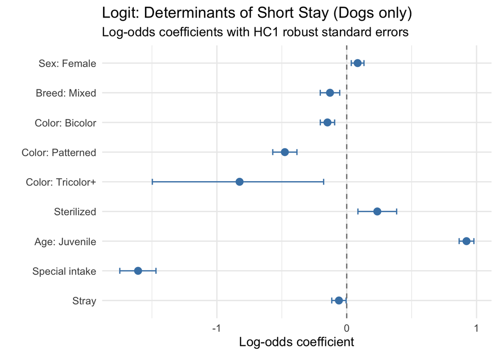

```r
# prepare for coefficient plot
coef_order_logit_dog <- c(
  "Sex: Female",
  "Breed: Mixed",
  "Color: Bicolor",
  "Color: Patterned",
  "Color: Tricolor+",
  "Sterilized",
  "Age: Juvenile",
  "Special intake",
  "Stray"
)

coef_plot_logit_dog <- tidy_logit_dog_hc1 %>%
  filter(term != "(Intercept)") %>%
  mutate(
    term = recode(
      term,
      "sexFemale"                = "Sex: Female",
      "is_mixedMixed"            = "Breed: Mixed",
      "color_typeBicolor"        = "Color: Bicolor",
      "color_typePatterned"      = "Color: Patterned",
      "color_typeTricolor+"      = "Color: Tricolor+",
      "sterilizedSterilized"     = "Sterilized",
      "age_groupJuvenile"        = "Age: Juvenile",
      "special_conditionSpecial" = "Special intake",
      "strayStray"               = "Stray"
    ),
    term = factor(term, levels = rev(coef_order_logit_dog))
  )

 # coefficient plot: logit, Dog
plot_logit_dog <- ggplot(coef_plot_logit_dog, aes(x = term, y = estimate)) +
  geom_point(size = 3, color = "steelblue") +
  geom_errorbar(aes(ymin = conf.low, ymax = conf.high),
                width = 0.2, color = "steelblue") +
  geom_hline(yintercept = 0, linetype = "dashed", color = "gray50") +
  coord_flip() +
  labs(
    title = "Logit: Determinants of Short Stay (Dogs only)",
    subtitle = "Log-odds coefficients with HC1 robust standard errors",
    x = "",
    y = "Log-odds coefficient"
  ) +
  theme_minimal(base_size = 13)
  plot_logit_dog
```

### c.2 Result table: Logit_dog

```r
# prepare for result table
tbl_logit_dog <- tidy_logit_dog_hc1 %>%
  filter(term != "(Intercept)") %>%
  mutate(
    term = recode(
      term,
      "sexFemale"                = "Sex: Female",
      "is_mixedMixed"            = "Breed: Mixed",
      "color_typeBicolor"        = "Color: Bicolor",
      "color_typePatterned"      = "Color: Patterned",
      "color_typeTricolor+"      = "Color: Tricolor+",
      "sterilizedSterilized"     = "Sterilized",
      "age_groupJuvenile"        = "Age: Juvenile",
      "special_conditionSpecial" = "Special intake",
      "strayStray"               = "Stray"
    ),
    sig  = star(p.value),
    est_with_star = ifelse(
      sig == "",
      sprintf("%.3f", estimate),
      sprintf("%.3f<sup>%s</sup>", estimate, sig)
    ),
    ci_col = sprintf("[%.3f, %.3f]", conf.low, conf.high)
  ) %>%
  transmute(
    Term = term,
    Estimate = est_with_star,
    `Std. Error (HC1)` = sprintf("%.3f", std.error),
    `95% CI` = ci_col,
    `p-value` = sprintf("%.3f", p.value)
  )

 # result table
g_stats_logit_dog <- glance(logit_dog)
y_mean_logit_dog  <- mean(austin_for_analysis_dog$los_index, na.rm = TRUE)

result_tbl_logit_dog <- tbl_logit_dog %>%
  gt() %>%
  tab_header(
    title = md("**Logit results with HC1 robust standard errors (Dogs only)**"),
    subtitle = md(
      glue(
        "Outcome: **los_index** (1 = stay ≤ species-specific median LOS for dogs).  ",
        "Mean outcome = **{sprintf('%.3f', y_mean_logit_dog)}**"
      )
    )
  ) %>%
  fmt_markdown(columns = "Estimate") %>%
  cols_label(
    Term = "Variable",
    Estimate = "Estimate (log-odds)",
    `Std. Error (HC1)` = "Std. Error (HC1)",
    `95% CI` = "95% CI",
    `p-value` = "p-value"
  ) %>%
  cols_align(
    align = "left",
    columns = c(Term)
  ) %>%
  cols_align(
    align = "right",
    columns = c("Estimate", "Std. Error (HC1)", "95% CI", "p-value")
  ) %>%
  tab_source_note(
    source_note = md(
      glue("**AIC** = {sprintf('%.1f', g_stats_logit_dog$AIC)}; ",
           "**N** = {g_stats_logit_dog$nobs}")
    )
  ) %>%
  tab_source_note(
    source_note = md(
      paste0(
        "**Base groups (Dogs):** Sex = Male; Breed = Purebred; Color = Solid; ",
        "Sterilization = Intact; Age = Adult; Intake condition = Normal; ",
        "Origin = Owned (vs Stray)."
      )
    )
  ) %>%
  tab_style(
    style = list(
      cell_text(size = "smaller", color = "gray40", align = "left")
    ),
    locations = cells_source_notes()
  ) %>%
  opt_row_striping()

result_tbl_logit_dog
```

**Logit results with HC1 robust standard errors (Dogs only)**

Outcome: **los_index** (1 = stay ≤ species-specific median LOS for dogs). Mean outcome = **0.574**

| Variable | Estimate (log-odds) | Std. Error (HC1) | 95% CI | p-value |
| --- | --- | --- | --- | --- |
| Sex: Female | 0.084*** | 0.025 | [0.035, 0.133] | 0.001 |
| Breed: Mixed | -0.129*** | 0.038 | [-0.204, -0.054] | 0.001 |
| Color: Bicolor | -0.148*** | 0.028 | [-0.203, -0.093] | 0.000 |
| Color: Tricolor+ | -0.825** | 0.334 | [-1.497, -0.178] | 0.013 |
| Color: Patterned | -0.477*** | 0.047 | [-0.570, -0.383] | 0.000 |
| Sterilized | 0.236*** | 0.076 | [0.086, 0.385] | 0.002 |
| Age: Juvenile | 0.923*** | 0.029 | [0.866, 0.980] | 0.000 |
| Special intake | -1.607*** | 0.071 | [-1.748, -1.469] | 0.000 |
| Stray | -0.060** | 0.028 | [-0.115, -0.005] | 0.033 |

**AIC** = 36608.2; **N** = 28101  
**Base groups (Dogs):** Sex = Male; Breed = Purebred; Color = Solid; Sterilization = Intact; Age = Adult; Intake condition = Normal; Origin = Owned (vs Stray).

### c.3 Save table & plot

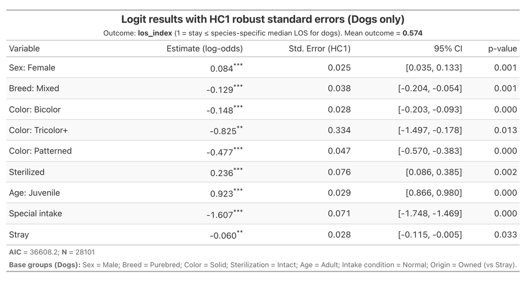

```r
# save table & plot
save_all_outputs(
  plot_obj  = plot_logit_dog,
  table_obj = result_tbl_logit_dog,
  name      = "logit_dog"
)
```

## D. LPM: Cat

```r
# 相較狗狗的迴歸結果，控制其他條件不變下，具有特別圖案的貓咪則較快被收養，本組推測許多貓咪的毛色帶有條紋，因此受到領養人的喜愛。
# 而狗狗則鮮少有具規律之特殊圖案，因此較無法受到市場的青睞。
lpm_cat <- lm(
  los_index ~ sex + is_mixed + color_type +
    sterilized + age_group + special_condition + stray,
  data = austin_for_analysis_cat
)

lpm_cat_summary <- tidy(lpm_cat, conf.int = TRUE)

# HC1 robust variance
vc_hc1_lpm_cat <- sandwich::vcovHC(lpm_cat, type = "HC1")
tidy_lpm_cat_hc1 <- broom::tidy(lpm_cat, conf.int = TRUE, vcov = vc_hc1_lpm_cat)
```

### d.1 Coefficient plot: LPM_cat

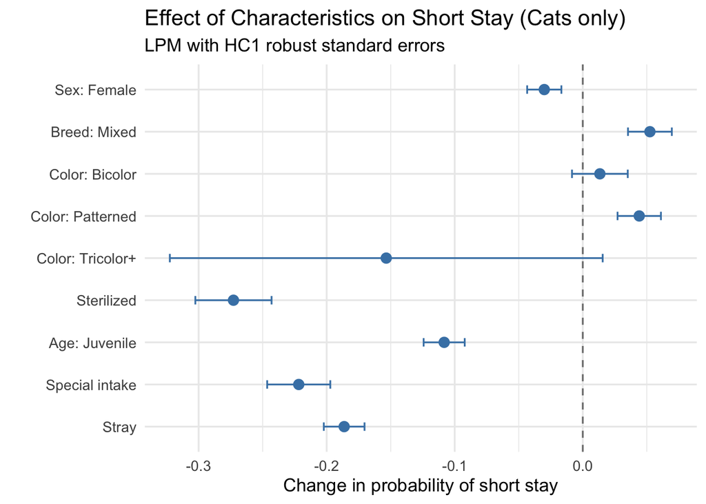

```r
# prepare for coefficient plot
coef_order_lpm_cat <- c(
  "Sex: Female",
  "Breed: Mixed",
  "Color: Bicolor",
  "Color: Patterned",
  "Color: Tricolor+",
  "Sterilized",
  "Age: Juvenile",
  "Special intake",
  "Stray"
)

coef_plot_lpm_cat <- tidy_lpm_cat_hc1 %>%
  filter(term != "(Intercept)") %>%
  mutate(
    term = recode(
      term,
      "sexFemale"                = "Sex: Female",
      "is_mixedMixed"            = "Breed: Mixed",
      "color_typeBicolor"        = "Color: Bicolor",
      "color_typePatterned"      = "Color: Patterned",
      "color_typeTricolor+"      = "Color: Tricolor+",
      "sterilizedSterilized"     = "Sterilized",
      "age_groupJuvenile"        = "Age: Juvenile",
      "special_conditionSpecial" = "Special intake",
      "strayStray"               = "Stray"
    ),
    term = factor(term, levels = rev(coef_order_lpm_cat))
  )

 # coefficient plot: lpm, Cat
plot_lpm_cat <- ggplot(coef_plot_lpm_cat, aes(x = term, y = estimate)) +
  geom_point(size = 3, color = "steelblue") +
  geom_errorbar(aes(ymin = conf.low, ymax = conf.high),
                width = 0.2, color = "steelblue") +
  geom_hline(yintercept = 0, linetype = "dashed", color = "gray50") +
  coord_flip() +
  labs(
    title = "Effect of Characteristics on Short Stay (Cats only)",
    subtitle = "LPM with HC1 robust standard errors",
    x = "",
    y = "Change in probability of short stay"
  ) +
  theme_minimal(base_size = 13)
  plot_lpm_cat
```

### d.2 Result table: LPM_cat

```r
# prepare for result table
tbl_lpm_cat <- tidy_lpm_cat_hc1 %>%
  filter(term != "(Intercept)") %>%
  mutate(
    term = recode(
      term,
      "sexFemale"                = "Sex: Female",
      "is_mixedMixed"            = "Breed: Mixed",
      "color_typeBicolor"        = "Color: Bicolor",
      "color_typePatterned"      = "Color: Patterned",
      "color_typeTricolor+"      = "Color: Tricolor+",
      "sterilizedSterilized"     = "Sterilized",
      "age_groupJuvenile"        = "Age: Juvenile",
      "special_conditionSpecial" = "Special intake",
      "strayStray"               = "Stray"
    ),
    sig  = star(p.value),
    est_with_star = ifelse(
      sig == "",
      sprintf("%.3f", estimate),
      sprintf("%.3f<sup>%s</sup>", estimate, sig)
    ),
    ci_col = sprintf("[%.3f, %.3f]", conf.low, conf.high)
  ) %>%
  transmute(
    Term = term,
    Estimate = est_with_star,
    `Std. Error (HC1)` = sprintf("%.3f", std.error),
    `95% CI` = ci_col,
    `p-value` = sprintf("%.3f", p.value)
  )

 # result table
g_stats_lpm_cat <- glance(lpm_cat)
y_mean_lpm_cat  <- mean(austin_for_analysis_cat$los_index, na.rm = TRUE)

result_tbl_lpm_cat <- tbl_lpm_cat %>%
  gt() %>%
  tab_header(
    title = md("**LPM results with HC1 robust standard errors (Cats only)**"),
    subtitle = md(
      glue("Outcome: **los_index** (1 = stay ≤ species-specific median LOS for cats).  ",
           "Mean outcome = **{sprintf('%.3f', y_mean_lpm_cat)}**")
    )
  ) %>%
  fmt_markdown(columns = "Estimate") %>%
  cols_label(
    Term = "Variable",
    Estimate = "Estimate",
    `Std. Error (HC1)` = "Std. Error (HC1)",
    `95% CI` = "95% CI",
    `p-value` = "p-value"
  ) %>%
  cols_align(
    align = "left",
    columns = c(Term)
  ) %>%
  cols_align(
    align = "right",
    columns = c("Estimate", "Std. Error (HC1)", "95% CI", "p-value")
  ) %>%
  tab_source_note(
    source_note = md(
      glue("**R²** = {sprintf('%.3f', g_stats_lpm_cat$r.squared)}; ",
           "**Adj. R²** = {sprintf('%.3f', g_stats_lpm_cat$adj.r.squared)}; ",
           "**N** = {g_stats_lpm_cat$nobs}")
    )
  ) %>%
  tab_source_note(
    source_note = md(
      paste0(
        "**Base groups (Cats):** Sex = Male; Breed = Purebred; Color = Solid; ",
        "Sterilization = Intact; Age = Adult; Intake condition = Normal; ",
        "Origin = Owned (vs Stray)."
      )
    )
  ) %>%
  tab_style(
    style = list(
      cell_text(size = "smaller", color = "gray40", align = "left")
    ),
    locations = cells_source_notes()
  ) %>%
  opt_row_striping()

result_tbl_lpm_cat
```

**LPM results with HC1 robust standard errors (Cats only)**

Outcome: **los_index** (1 = stay ≤ species-specific median LOS for cats). Mean outcome = **0.523**

| Variable | Estimate | Std. Error (HC1) | 95% CI | p-value |
| --- | --- | --- | --- | --- |
| Sex: Female | -0.030*** | 0.007 | [-0.043, -0.017] | 0.000 |
| Breed: Mixed | 0.052*** | 0.009 | [0.035, 0.070] | 0.000 |
| Color: Bicolor | 0.013 | 0.011 | [-0.008, 0.035] | 0.229 |
| Color: Tricolor+ | -0.153* | 0.086 | [-0.323, 0.016] | 0.075 |
| Color: Patterned | 0.044*** | 0.009 | [0.027, 0.061] | 0.000 |
| Sterilized | -0.273*** | 0.015 | [-0.303, -0.243] | 0.000 |
| Age: Juvenile | -0.108*** | 0.008 | [-0.124, -0.092] | 0.000 |
| Special intake | -0.222*** | 0.013 | [-0.246, -0.197] | 0.000 |
| Stray | -0.186*** | 0.008 | [-0.202, -0.170] | 0.000 |

**R²** = 0.084; **Adj. R²** = 0.083; **N** = 19885  
**Base groups (Cats):** Sex = Male; Breed = Purebred; Color = Solid; Sterilization = Intact; Age = Adult; Intake condition = Normal; Origin = Owned (vs Stray).

### d.3 Save table & plot

```r
# save table & plot
# save_all_outputs(
#   plot_obj  = plot_lpm_cat,
#   table_obj = result_tbl_lpm_cat,
#   name      = "lpm_cat"
# )
```

## E. Logit: Cat

```r
logit_cat <- glm(
  los_index ~ sex + is_mixed + color_type +
    sterilized + age_group + special_condition + stray,
  data   = austin_for_analysis_cat,
  family = binomial(link = "logit")
)

# HC1 robust variance
vc_hc1_logit_cat <- sandwich::vcovHC(logit_cat, type = "HC1")
tidy_logit_cat_hc1 <- broom::tidy(logit_cat, conf.int = TRUE, vcov = vc_hc1_logit_cat)
```

### e.1 Coefficient plot: Logit_cat

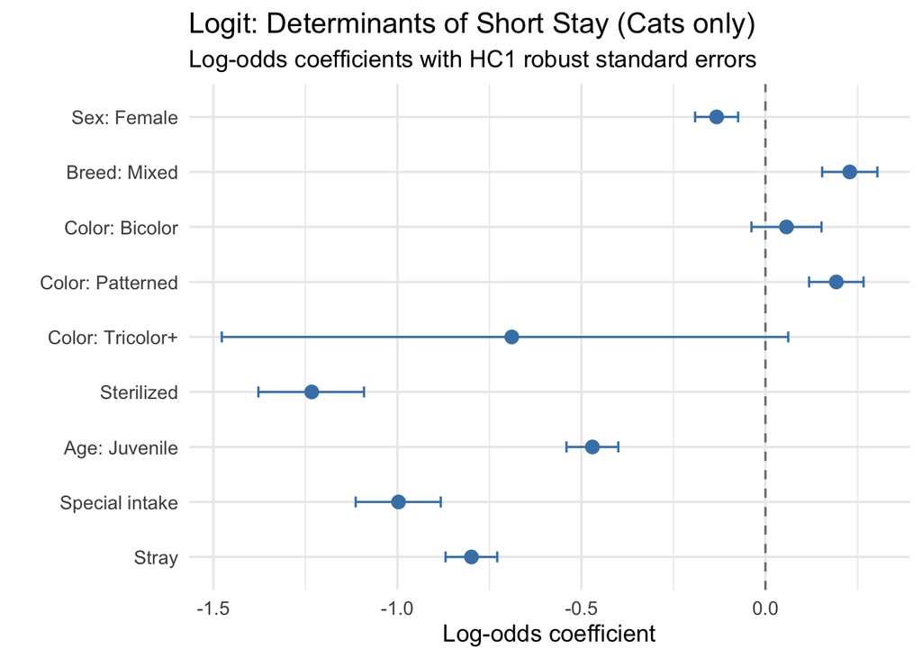

```r
# prepare for coefficient plot
coef_order_logit_cat <- coef_order_lpm_cat

coef_plot_logit_cat <- tidy_logit_cat_hc1 %>%
  filter(term != "(Intercept)") %>%
  mutate(
    term = recode(
      term,
      "sexFemale"                = "Sex: Female",
      "is_mixedMixed"            = "Breed: Mixed",
      "color_typeBicolor"        = "Color: Bicolor",
      "color_typePatterned"      = "Color: Patterned",
      "color_typeTricolor+"      = "Color: Tricolor+",
      "sterilizedSterilized"     = "Sterilized",
      "age_groupJuvenile"        = "Age: Juvenile",
      "special_conditionSpecial" = "Special intake",
      "strayStray"               = "Stray"
    ),
    term = factor(term, levels = rev(coef_order_logit_cat))
  )

 # coefficient plot: logit, Cat
plot_logit_cat <- ggplot(coef_plot_logit_cat, aes(x = term, y = estimate)) +
  geom_point(size = 3, color = "steelblue") +
  geom_errorbar(aes(ymin = conf.low, ymax = conf.high),
                width = 0.2, color = "steelblue") +
  geom_hline(yintercept = 0, linetype = "dashed", color = "gray50") +
  coord_flip() +
  labs(
    title = "Logit: Determinants of Short Stay (Cats only)",
    subtitle = "Log-odds coefficients with HC1 robust standard errors",
    x = "",
    y = "Log-odds coefficient"
  ) +
  theme_minimal(base_size = 13)
  plot_logit_cat
```

### e.2 Result table: Logit_cat

```r
# prepare for result table
tbl_logit_cat <- tidy_logit_cat_hc1 %>%
  filter(term != "(Intercept)") %>%
  mutate(
    term = recode(
      term,
      "sexFemale"                = "Sex: Female",
      "is_mixedMixed"            = "Breed: Mixed",
      "color_typeBicolor"        = "Color: Bicolor",
      "color_typePatterned"      = "Color: Patterned",
      "color_typeTricolor+"      = "Color: Tricolor+",
      "sterilizedSterilized"     = "Sterilized",
      "age_groupJuvenile"        = "Age: Juvenile",
      "special_conditionSpecial" = "Special intake",
      "strayStray"               = "Stray"
    ),
    sig  = star(p.value),
    est_with_star = ifelse(
      sig == "",
      sprintf("%.3f", estimate),
      sprintf("%.3f<sup>%s</sup>", estimate, sig)
    ),
    ci_col = sprintf("[%.3f, %.3f]", conf.low, conf.high)
  ) %>%
  transmute(
    Term = term,
    Estimate = est_with_star,
    `Std. Error (HC1)` = sprintf("%.3f", std.error),
    `95% CI` = ci_col,
    `p-value` = sprintf("%.3f", p.value)
  )

 # result table
g_stats_logit_cat <- glance(logit_cat)
y_mean_logit_cat  <- mean(austin_for_analysis_cat$los_index, na.rm = TRUE)

result_tbl_logit_cat <- tbl_logit_cat %>%
  gt() %>%
  tab_header(
    title = md("**Logit results with HC1 robust standard errors (Cats only)**"),
    subtitle = md(
      glue("Outcome: **los_index** (1 = stay ≤ species-specific median LOS for cats).  ",
           "Mean outcome = **{sprintf('%.3f', y_mean_logit_cat)}**")
    )
  ) %>%
  fmt_markdown(columns = "Estimate") %>%
  cols_label(
    Term = "Variable",
    Estimate = "Estimate (log-odds)",
    `Std. Error (HC1)` = "Std. Error (HC1)",
    `95% CI` = "95% CI",
    `p-value` = "p-value"
  ) %>%
  cols_align(
    align = "left",
    columns = c(Term)
  ) %>%
  cols_align(
    align = "right",
    columns = c("Estimate", "Std. Error (HC1)", "95% CI", "p-value")
  ) %>%
  tab_source_note(
    source_note = md(
      glue("**AIC** = {sprintf('%.1f', g_stats_logit_cat$AIC)}; ",
           "**N** = {g_stats_logit_cat$nobs}")
    )
  ) %>%
  tab_source_note(
    source_note = md(
      paste0(
        "**Base groups (Cats):** Sex = Male; Breed = Purebred; Color = Solid; ",
        "Sterilization = Intact; Age = Adult; Intake condition = Normal; ",
        "Origin = Owned (vs Stray)."
      )
    )
  ) %>%
  tab_style(
    style = list(
      cell_text(size = "smaller", color = "gray40", align = "left")
    ),
    locations = cells_source_notes()
  ) %>%
  opt_row_striping()

result_tbl_logit_cat
```

**Logit results with HC1 robust standard errors (Cats only)**

Outcome: **los_index** (1 = stay ≤ species-specific median LOS for cats). Mean outcome = **0.523**

| Variable | Estimate (log-odds) | Std. Error (HC1) | 95% CI | p-value |
| --- | --- | --- | --- | --- |
| Sex: Female | -0.133*** | 0.030 | [-0.191, -0.074] | 0.000 |
| Breed: Mixed | 0.229*** | 0.038 | [0.154, 0.304] | 0.000 |
| Color: Bicolor | 0.057 | 0.049 | [-0.038, 0.152] | 0.239 |
| Color: Tricolor+ | -0.689* | 0.389 | [-1.477, 0.062] | 0.077 |
| Color: Patterned | 0.193*** | 0.038 | [0.119, 0.267] | 0.000 |
| Sterilized | -1.233*** | 0.073 | [-1.378, -1.091] | 0.000 |
| Age: Juvenile | -0.470*** | 0.036 | [-0.541, -0.400] | 0.000 |
| Special intake | -0.997*** | 0.059 | [-1.113, -0.882] | 0.000 |
| Stray | -0.799*** | 0.036 | [-0.869, -0.729] | 0.000 |

**AIC** = 25803.9; **N** = 19885  
**Base groups (Cats):** Sex = Male; Breed = Purebred; Color = Solid; Sterilization = Intact; Age = Adult; Intake condition = Normal; Origin = Owned (vs Stray).

### e.3 Save table & plot

```r
# save table & plot
# save_all_outputs(
#   plot_obj  = plot_logit_cat,
#   table_obj = result_tbl_logit_cat,
#   name      = "logit_cat"
# )
```

## 1. Dog: LPM vs Logit

```r
# LPM vs Logit
var_label_map <- c(
  sexFemale                = "Sex: Female",
  is_mixedMixed            = "Breed: Mixed",
  color_typeBicolor        = "Color: Bicolor",
  color_typePatterned      = "Color: Patterned",
  `color_typeTricolor+`    = "Color: Tricolor+",
  sterilizedSterilized     = "Sterilized",
  age_groupJuvenile        = "Age: Juvenile",
  special_conditionSpecial = "Special intake",
  strayStray               = "Stray"
)

var_order <- c(
  "Sex: Female",
  "Breed: Mixed",
  "Color: Bicolor",
  "Color: Patterned",
  "Color: Tricolor+",
  "Sterilized",
  "Age: Juvenile",
  "Special intake",
  "Stray"
)

 ## for model of dog
# 平均邊際效果（Average Marginal Effects, AME）
me_dog <- margins::margins(logit_dog, vcov = vc_hc1_logit_dog)
me_dog_sum <- summary(me_dog)  # data.frame: factor, AME, SE, z, p, lower, upper

# LPM_dog row：把估計值＋星號組成文字
lpm_dog_row <- tidy_lpm_dog_hc1 %>%
  dplyr::filter(term != "(Intercept)") %>%
  dplyr::mutate(
    var_label = dplyr::recode(term, !!!var_label_map),
    sig       = star(p.value),
    value     = sprintf("%.3f%s", estimate, sig)
  ) %>%
  dplyr::select(var_label, value) %>%
  dplyr::filter(!is.na(var_label))

# Logit_dog AME row
logit_dog_row <- me_dog_sum %>%
  dplyr::mutate(
    term      = factor,
    var_label = dplyr::recode(as.character(term), !!!var_label_map),
    sig       = star(p),
    value     = sprintf("%.3f%s", AME, sig)
  ) %>%
  dplyr::select(var_label, value) %>%
  dplyr::filter(!is.na(var_label))

# 狗：長 → 寬
comp_dog_long <- bind_rows(
  lpm_dog_row  %>% mutate(Model = "LPM"),
  logit_dog_row %>% mutate(Model = "Logit (AME)")
)

comp_dog_wide <- comp_dog_long %>%
  mutate(var_label = factor(var_label, levels = var_order)) %>%
  arrange(Model, var_label) %>%
  tidyr::pivot_wider(
    names_from  = var_label,
    values_from = value
  )

# 變成 gt table，並讓星號變成右上角（用 markdown）
comp_dog_tbl <- comp_dog_wide %>%
  gt() %>%
  tab_header(
    title    = md("**Dogs: LPM vs Logit (Average Marginal Effects)**"),
    subtitle = md("Rows = model, Columns = covariates; Logit entries are AME")
  ) %>%
  fmt_markdown(columns = -Model) %>%  # 把 <sup> 解析成上標
  cols_label(Model = "Model") %>%
  opt_row_striping()

comp_dog_tbl
```

**Dogs: LPM vs Logit (Average Marginal Effects)**

Rows = model, Columns = covariates; Logit entries are AME

| Model | Sex: Female | Breed: Mixed | Color: Bicolor | Color: Patterned | Color: Tricolor+ | Sterilized | Age: Juvenile | Special intake | Stray |
| --- | --- | --- | --- | --- | --- | --- | --- | --- | --- |
| LPM | 0.019*** | -0.029*** | -0.034*** | -0.111*** | -0.195** | 0.053*** | 0.208*** | -0.355*** | -0.014** |
| Logit (AME) | 0.019*** | -0.029*** | -0.034*** | -0.111*** | -0.192** | 0.055*** | 0.208*** | -0.353*** | -0.014** |

### 1-1. Save Dog: LPM vs Logit table

```r
# gtsave(comp_dog_tbl, "/Users/nnychhi/Desktop/austin_outputs/table/comp_dog_lpm_logit.html")
# webshot2::webshot("/Users/nnychhi/Desktop/austin_outputs/table/comp_dog_lpm_logit.html",
#                   file = "/Users/nnychhi/Desktop/austin_outputs/table/comp_dog_lpm_logit.png", zoom = 2)
```

## 2. Cat: LPM vs Logit

```r
 ## for model of cat
me_cat <- margins::margins(logit_cat, vcov = vc_hc1_logit_cat)
me_cat_sum <- summary(me_cat)

lpm_cat_row <- tidy_lpm_cat_hc1 %>%
  dplyr::filter(term != "(Intercept)") %>%
  dplyr::mutate(
    var_label = dplyr::recode(term, !!!var_label_map),
    sig       = star(p.value),
    value     = sprintf("%.3f%s", estimate, sig)
  ) %>%
  dplyr::select(var_label, value) %>%
  dplyr::filter(!is.na(var_label))

logit_cat_row <- me_cat_sum %>%
  dplyr::mutate(
    term      = factor,
    var_label = dplyr::recode(as.character(term), !!!var_label_map),
    sig       = star(p),
    value     = sprintf("%.3f%s", AME, sig)
  ) %>%
  dplyr::select(var_label, value) %>%
  dplyr::filter(!is.na(var_label))

comp_cat_long <- bind_rows(
  lpm_cat_row   %>% mutate(Model = "LPM"),
  logit_cat_row %>% mutate(Model = "Logit (AME)")
)

comp_cat_wide <- comp_cat_long %>%
  mutate(var_label = factor(var_label, levels = var_order)) %>%
  arrange(Model, var_label) %>%
  tidyr::pivot_wider(
    names_from  = var_label,
    values_from = value
  )

comp_cat_tbl <- comp_cat_wide %>%
  gt() %>%
  tab_header(
    title    = md("**Cats: LPM vs Logit (Average Marginal Effects)**"),
    subtitle = md("Rows = model, Columns = covariates; Logit entries are AME")
  ) %>%
  fmt_markdown(columns = -Model) %>%
  cols_label(Model = "Model") %>%
  opt_row_striping()

comp_cat_tbl
```

**Cats: LPM vs Logit (Average Marginal Effects)**

Rows = model, Columns = covariates; Logit entries are AME

[output not shown]

### 2-1. Save Cat: LPM vs Logit table

```r
# gtsave(comp_cat_tbl, "/Users/nnychhi/Desktop/austin_outputs/table/comp_cat_lpm_logit.html")
# webshot2::webshot("/Users/nnychhi/Desktop/austin_outputs/table/comp_cat_lpm_logit.html",
#                   file = "/Users/nnychhi/Desktop/austin_outputs/table/comp_cat_lpm_logit.png", zoom = 2)
```

- Supplementary: interaction OLS & Cox model

```r
## OLS with interaction: animal x color ---
# lm_inter <- lm(
#   log_stay_day_round ~
#     animal_type * color_type +
#     animal_type * sterilized +
#     sex +
#     is_mixed,
#   data = austin_for_analysis
# )
#
# vc_hc1_lm_inter <- sandwich::vcovHC(lm_inter, type = "HC1")
# tidy_inter <- broom::tidy(lm_inter, conf.int = TRUE, vcov = vc_hc1_lm_inter)
#
# order_inter <- c(
#   "Animal: Cat",
#   "Sex: Female",
#   "Sterilized",
#   "Breed: Mixed",
#   "Color: Bicolor",
#   "Color: Patterned",
#   "Color: Tricolor+",
#   "Cat × Bicolor",
#   "Cat × Patterned",
#   "Cat × Tricolor+",
#   "Cat × Sterilized"
# )
#
# tidy_inter2 <- tidy_inter %>%
#   filter(term != "(Intercept)") %>%
#   mutate(
#     term = recode(term,
#                   # main effects
#                   "animal_typeCat"           = "Animal: Cat",
#                   "color_typeBicolor"        = "Color: Bicolor",
#                   "color_typeTricolor+"      = "Color: Tricolor+",
#                   "color_typePatterned"      = "Color: Patterned",
#                   "sterilizedSterilized"     = "Sterilized",
#                   "sexFemale"                = "Sex: Female",
#                   "is_mixedMixed"            = "Breed: Mixed",
#
#                   # interaction terms
#                   "animal_typeCat:color_typeBicolor"   = "Cat × Bicolor",
#                   "animal_typeCat:color_typeTricolor+" = "Cat × Tricolor+",
#                   "animal_typeCat:color_typePatterned" = "Cat × Patterned",
#                   "animal_typeCat:sterilizedSterilized"= "Cat × Sterilized"
#     ),
#     term = factor(term, levels = rev(order_inter)),
#     sig = case_when(
#       p.value < 0.01 ~ "***",
#       p.value < 0.05 ~ "**",
#       p.value < 0.10 ~ "*",
#       TRUE ~ ""
#     ),
#     est_with_star = if_else(
#       sig == "",
#       sprintf("%.3f", estimate),
#       sprintf("%.3f<sup>%s</sup>", estimate, sig)
#     ),
#     ci_col = sprintf("[%.3f, %.3f]", conf.low, conf.high)
#   )
#
# ggplot(tidy_inter2, aes(x = term, y = estimate)) +
#   geom_point(size=3, color="steelblue") +
#   geom_errorbar(aes(ymin = conf.low, ymax = conf.high), width = 0.2, color="steelblue") +
#   geom_hline(yintercept = 0, linetype="dashed", color="gray50") +
#   coord_flip() +
#   labs(
#     title = "Interaction Effects on Days to Adoption (log(1 + days))",
#     subtitle = "OLS with interactions: Animal × Color, Animal × Sterilized (HC1 SE)",
#     x = "",
#     y = "Coefficient"
#   ) +
#   theme_minimal(base_size = 13)
#
# tbl_inter <- tidy_inter2 %>%
#   transmute(
#     Term = term,
#     Estimate = est_with_star,
#     `Std. Error (HC1)` = sprintf("%.3f", std.error),
#     `95% CI` = ci_col,
#     `p-value` = sprintf("%.3f", p.value)
#   )
#
# g_stats_inter <- glance(lm_inter)
# y_mean <- mean(austin_for_analysis$log_stay_day_round)
#
# result_tbl_inter <- tbl_inter %>%
#   gt() %>%
#   tab_header(
#     title = md("**OLS Interaction Model with HC1 robust standard errors**"),
#     subtitle = md(glue("Outcome mean (log(1 + days)) = **{sprintf('%.3f', y_mean)}**"))
#   ) %>%
#   fmt_markdown(columns = "Estimate") %>%
#   cols_align(
#     align = "left", columns = vars(Term)
#   ) %>%
#   cols_align(
#     align = "right",
#     columns = c("Estimate", "Std. Error (HC1)", "95% CI", "p-value")
#   ) %>%
#   tab_source_note(
#     source_note = md(
#       glue("**R²** = {sprintf('%.3f', g_stats_inter$r.squared)}; ",
#            "**Adj. R²** = {sprintf('%.3f', g_stats_inter$adj.r.squared)}; ",
#            "**N** = {g_stats_inter$nobs}")
#     )
#   ) %>%
#   tab_source_note(
#     source_note = md(
#       "**Base groups:**
#       Animal = Dog;
#       Sterilization = Intact;
#       Sex = Male;
#       Breed = Purebred;
#       Color = Solid."
#     )
#   ) %>%
#   opt_row_striping()
#
# # cox model
# cox_fit <- coxph(
#   Surv(stay_day_round, event = rep(1, nrow(austin_for_analysis))) ~
#     animal_type * color_type +
#     animal_type * sterilized +
#     sex + is_mixed,
#   data = austin_for_analysis
# )
#
# summary(cox_fit)
```